# 노인비율데이터pca

```python
import pandas as pd
import seaborn as sns
import numpy as np
```

```python
!apt-get update -qq
!apt-get install fonts-nanum* -qq
```

```python
import matplotlib.pyplot as plt
import matplotlib as mpl
%matplotlib inline

plt.rcParams['axes.unicode_minus'] = False

path = '/usr/share/fonts/truetype/nanum/NanumGothic.ttf'
font_name = mpl.font_manager.FontProperties(fname=path).get_name()
mpl.rc('font', family=font_name)
mpl.font_manager._rebuild()
```

[figure not shown]

```python
import matplotlib.pyplot as plt
import matplotlib as mpl
%matplotlib inline

plt.rcParams['axes.unicode_minus'] = False

path = '/usr/share/fonts/truetype/nanum/NanumGothic.ttf'
font_name = mpl.font_manager.FontProperties(fname=path).get_name()
mpl.rc('font', family=font_name)
mpl.font_manager._rebuild()
plt.title('테스트')
```

```python
df = pd.read_csv('/content/drive/Shareddrives/데마 팀플 2/텀프로젝트/공간데이터/노인데이터pca/노인 비율 Data.csv',thousands=',')
```

```python
df.head()
```

|  | 시군구 | 노인 수 | 노인 일자리 비율 | 종합 복지시설 비율 | 복지공무원 비율 | 노령화지수 (%) | 노년부양비 (%) | 독거노인 가구 비율 | 빈곤율 | 1인당 GRDP (만원,2016) | 노인빈곤 순위 소계 | 도시락 배달 비율 | 무료 급식소 비율 |
| --- | --- | --- | --- | --- | --- | --- | --- | --- | --- | --- | --- | --- | --- |
| 0 | 가평군 | 16626 | 0.119 | 0.01106 | 0.00589 | 266.70 | 37.43 | 12.4 | 27.3 | 2517 | 99 | 0.000360 | 0.000060 |
| 1 | 고양시 | 149289 | 0.043 | 0.00403 | 0.00351 | 100.91 | 16.97 | 5.5 | 14.8 | 1875 | 84 | 0.000060 | 0.000087 |
| 2 | 과천시 | 9694 | 0.038 | 0.00391 | 0.00680 | 109.58 | 18.88 | 5.8 | 8.4 | 4600 | 25 | 0.000103 | 0.000103 |
| 3 | 광명시 | 42123 | 0.050 | 0.00306 | 0.00384 | 100.74 | 17.69 | 6.3 | 15.3 | 1964 | 76 | 0.000094 | 0.000142 |
| 4 | 광주시 | 52902 | 0.031 | 0.00576 | 0.00372 | 88.26 | 16.93 | 4.3 | 9.1 | 2359 | 24 | 0.000018 | 0.000018 |

```python
df.columns
```

```
Index(['시군구', '노인 수', '노인 일자리 비율', '종합 복지시설 비율', '복지공무원 비율', '노령화지수 (%)',
       '노년부양비 (%)', '독거노인 가구 비율', '빈곤율', '1인당 GRDP (만원,2016)', '노인빈곤 순위 소계',
       '도시락 배달 비율', '무료 급식소 비율'],
      dtype='object')
```

```python
df.rename(columns = {'노령화지수 (%)':'노령화지수','노년부양비 (%)':'노년부양비','1인당 GRDP (만원,2016)':'1인당 GRDP'},inplace=True)
```

```python
df.columns
```

```
Index(['시군구', '노인 수', '노인 일자리 비율', '종합 복지시설 비율', '복지공무원 비율', '노령화지수', '노년부양비',
       '독거노인 가구 비율', '빈곤율', '1인당 GRDP', '노인빈곤 순위 소계', '도시락 배달 비율',
       '무료 급식소 비율'],
      dtype='object')
```

```python
df.set_index('시군구',inplace=True)
```

```python
df.head(5)
```

| 시군구 | 노인 수 | 노인 일자리 비율 | 종합 복지시설 비율 | 복지공무원 비율 | 노령화지수 | 노년부양비 | 독거노인 가구 비율 | 빈곤율 | 1인당 GRDP | 노인빈곤 순위 소계 | 도시락 배달 비율 | 무료 급식소 비율 |
| --- | --- | --- | --- | --- | --- | --- | --- | --- | --- | --- | --- | --- |
| 가평군 | 16626 | 0.119 | 0.01106 | 0.00589 | 266.70 | 37.43 | 12.4 | 27.3 | 2517 | 99 | 0.000360 | 0.000060 |
| 고양시 | 149289 | 0.043 | 0.00403 | 0.00351 | 100.91 | 16.97 | 5.5 | 14.8 | 1875 | 84 | 0.000060 | 0.000087 |
| 과천시 | 9694 | 0.038 | 0.00391 | 0.00680 | 109.58 | 18.88 | 5.8 | 8.4 | 4600 | 25 | 0.000103 | 0.000103 |
| 광명시 | 42123 | 0.050 | 0.00306 | 0.00384 | 100.74 | 17.69 | 6.3 | 15.3 | 1964 | 76 | 0.000094 | 0.000142 |
| 광주시 | 52902 | 0.031 | 0.00576 | 0.00372 | 88.26 | 16.93 | 4.3 | 9.1 | 2359 | 24 | 0.000018 | 0.000018 |

```python
df.info()
```

```
<class 'pandas.core.frame.DataFrame'>
Index: 31 entries, 가평군 to 화성시
Data columns (total 12 columns):
 #   Column      Non-Null Count  Dtype
---  ------      --------------  -----
 0   노인 수        31 non-null     int64
 1   노인 일자리 비율   31 non-null     float64
 2   종합 복지시설 비율  31 non-null     float64
 3   복지공무원 비율    31 non-null     float64
 4   노령화지수       31 non-null     float64
 5   노년부양비       31 non-null     float64
 6   독거노인 가구 비율  31 non-null     float64
 7   빈곤율         31 non-null     float64
 8   1인당 GRDP    31 non-null     int64
 9   노인빈곤 순위 소계  31 non-null     int64
 10  도시락 배달 비율   31 non-null     float64
 11  무료 급식소 비율   31 non-null     float64
dtypes: float64(9), int64(3)
memory usage: 3.1+ KB
```

```python
df.index
```

```
Index(['가평군', '고양시', '과천시', '광명시', '광주시', '구리시', '군포시', '김포시', '남양주시', '동두천시',
       '부천시', '성남시', '수원시', '시흥시', '안산시', '안성시', '안양시', '양주시', '양평군', '여주시',
       '연천군', '오산시', '용인시', '의왕시', '의정부시', '이천시', '파주시', '평택시', '포천시', '하남시',
       '화성시'],
      dtype='object', name='시군구')
```

## Scaling

StandardScaler 이용

```python
import matplotlib.pyplot as plt
```

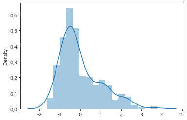

```python
from sklearn.preprocessing import StandardScaler
standard_scaler = StandardScaler()
df_standard = standard_scaler.fit_transform(df)
df_std = pd.DataFrame(df_standard,columns=df.columns)


fig, ax = plt.subplots(ncols=1)
sns.distplot(df_std)
```

```python
df_std.head()
```

|  | 노인 수 | 노인 일자리 비율 | 종합 복지시설 비율 | 복지공무원 비율 | 노령화지수 | 노년부양비 | 독거노인 가구 비율 | 빈곤율 | 1인당 GRDP | 노인빈곤 순위 소계 | 도시락 배달 비율 | 무료 급식소 비율 |
| --- | --- | --- | --- | --- | --- | --- | --- | --- | --- | --- | --- | --- |
| 0 | -1.034868 | 2.207812 | 1.212486 | 1.208381 | 2.807343 | 2.420274 | 2.422223 | 1.013676 | -0.295415 | 1.063113 | 2.829248 | -0.601457 |
| 1 | 2.231519 | -0.702991 | -0.848967 | -1.063068 | -0.262119 | -0.425265 | -0.399746 | -0.689704 | -0.766365 | 0.607493 | -0.422359 | -0.153176 |
| 2 | -1.205545 | -0.894491 | -0.884156 | 2.076877 | -0.101601 | -0.159626 | -0.277052 | -1.561834 | 1.232607 | -1.184611 | 0.043704 | 0.112472 |
| 3 | -0.407089 | -0.434891 | -1.133407 | -0.748119 | -0.265266 | -0.325129 | -0.072561 | -0.621569 | -0.701078 | 0.364496 | -0.053844 | 0.759989 |
| 4 | -0.141691 | -1.162592 | -0.341668 | -0.862646 | -0.496323 | -0.430828 | -0.890523 | -1.466445 | -0.411319 | -1.214986 | -0.877584 | -1.298784 |

## EDA

### 1. Correlation 확인

```python
df_std.corr()
```

|  | 노인 수 | 노인 일자리 비율 | 종합 복지시설 비율 | 복지공무원 비율 | 노령화지수 | 노년부양비 | 독거노인 가구 비율 | 빈곤율 | 1인당 GRDP | 노인빈곤 순위 소계 | 도시락 배달 비율 | 무료 급식소 비율 |
| --- | --- | --- | --- | --- | --- | --- | --- | --- | --- | --- | --- | --- |
| 노인 수 | 1.000000 | -0.633929 | -0.438281 | -0.328373 | -0.414377 | -0.440140 | -0.434593 | -0.354667 | -0.008807 | -0.144144 | -0.308568 | -0.114551 |
| 노인 일자리 비율 | -0.633929 | 1.000000 | 0.504971 | 0.469033 | 0.613154 | 0.580077 | 0.630172 | 0.512071 | -0.181846 | 0.283219 | 0.587028 | 0.197754 |
| 종합 복지시설 비율 | -0.438281 | 0.504971 | 1.000000 | 0.128869 | 0.508226 | 0.588855 | 0.516135 | 0.639031 | 0.370642 | 0.388700 | 0.200661 | -0.228158 |
| 복지공무원 비율 | -0.328373 | 0.469033 | 0.128869 | 1.000000 | 0.125112 | 0.025039 | 0.126953 | -0.110158 | 0.409417 | 0.022995 | 0.402056 | 0.390558 |
| 노령화지수 | -0.414377 | 0.613154 | 0.508226 | 0.125112 | 1.000000 | 0.969412 | 0.972073 | 0.657309 | -0.275525 | 0.381090 | 0.623719 | -0.259008 |
| 노년부양비 | -0.440140 | 0.580077 | 0.588855 | 0.025039 | 0.969412 | 1.000000 | 0.966722 | 0.764695 | -0.246240 | 0.376123 | 0.563306 | -0.324503 |
| 독거노인 가구 비율 | -0.434593 | 0.630172 | 0.516135 | 0.126953 | 0.972073 | 0.966722 | 1.000000 | 0.736890 | -0.261834 | 0.362862 | 0.611225 | -0.216993 |
| 빈곤율 | -0.354667 | 0.512071 | 0.639031 | -0.110158 | 0.657309 | 0.764695 | 0.736890 | 1.000000 | -0.095238 | 0.340480 | 0.413732 | -0.252825 |
| 1인당 GRDP | -0.008807 | -0.181846 | 0.370642 | 0.409417 | -0.275525 | -0.246240 | -0.261834 | -0.095238 | 1.000000 | -0.014137 | -0.085399 | 0.074163 |
| 노인빈곤 순위 소계 | -0.144144 | 0.283219 | 0.388700 | 0.022995 | 0.381090 | 0.376123 | 0.362862 | 0.340480 | -0.014137 | 1.000000 | 0.344918 | -0.203676 |
| 도시락 배달 비율 | -0.308568 | 0.587028 | 0.200661 | 0.402056 | 0.623719 | 0.563306 | 0.611225 | 0.413732 | -0.085399 | 0.344918 | 1.000000 | -0.151474 |
| 무료 급식소 비율 | -0.114551 | 0.197754 | -0.228158 | 0.390558 | -0.259008 | -0.324503 | -0.216993 | -0.252825 | 0.074163 | -0.203676 | -0.151474 | 1.000000 |

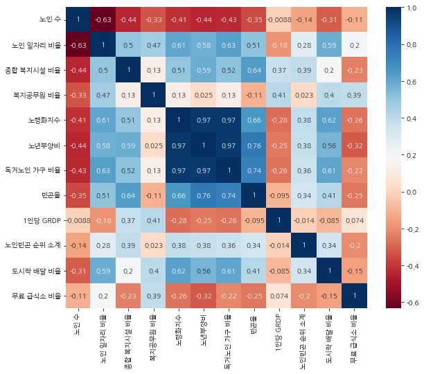

```python
f, ax = plt.subplots(figsize=(10, 8))
corr = df.corr()
sns.heatmap(corr, annot=True, mask=np.zeros_like(corr, dtype=np.bool), cmap="RdBu",
            square=True, ax=ax)
```

## PCA

```python
!pip install factor_analyzer
```

```python
from sklearn.decomposition import PCA

from factor_analyzer import FactorAnalyzer
```

### 1. PC 수 선택

```python
pca = PCA(random_state=312)
df_p = pca.fit_transform(df_std)
```

```python
fa = FactorAnalyzer(n_factors=df_std.shape[1], rotation=None) # rotation:
fa.fit(df_std)

ev, v = fa.get_eigenvalues()
print('eigen value:', ev,'\n')

print('적합한 PC 개수:', sum(ev >= 1))
```

```
eigen value: [5.17919428 1.86971737 1.3887347  0.84771122 0.73762357 0.38952865
 0.34701766 0.16312058 0.0440468  0.02063624 0.01266893]

적합한 PC 개수: 3
```

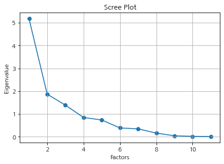

```python
plt.scatter(range(1, df_std.shape[1]+1),ev)
plt.plot(range(1,df_std.shape[1]+1),ev)
plt.title('Scree Plot')
plt.xlabel('Factors')
plt.ylabel('Eigenvalue')
plt.grid()
plt.show()
```

Factors 가 (3->4) 이후로 (4->5) 에서 기울기가 완만해짐 따라서 적합한 PC개수는 3

```python
each_variance_ratio = pca.explained_variance_ratio_
print('분산 설명 비율:\n', each_variance_ratio) # 각 PC별 분산 설명 비율

cumsum = np.cumsum(each_variance_ratio)
print('누적 분산 설명 비율:\n', cumsum)
```

```
분산 설명 비율:
 [0.47083584 0.16997431 0.12624861 0.07706466 0.06705669 0.0354117
 0.03154706 0.01482914 0.00400425 0.00187602 0.00115172]
누적 분산 설명 비율:
 [0.47083584 0.64081015 0.76705876 0.84412341 0.9111801  0.9465918
 0.97813886 0.992968   0.99697226 0.99884828 1.        ]
```

```python
d = np.argmax(cumsum >= 0.80) +1 #누적된 설명가능한 분산의 비율이 0.85 이상
print('적합한 PC 개수:', d)
```

```
적합한 PC 개수: 4
```

### 2. PCA 진행

```python
pca = PCA(n_components=4,random_state=312) # n_components를 재설정
pca_out = pca.fit(df_std)
df_p = pca.fit_transform(df_std)
```

```python
pca_pd = pd.DataFrame(pca.components_.T,
             columns = ['PC1','PC2','PC3','PC4'],
             index=df.columns)
pca_pd
```

|  | PC1 | PC2 | PC3 | PC4 |
| --- | --- | --- | --- | --- |
| 노인 일자리 비율 | 0.323832 | 0.312715 | -0.223439 | 0.165745 |
| 종합 복지시설 비율 | 0.290927 | 0.108390 | 0.523975 | 0.305469 |
| 복지공무원 비율 | 0.075578 | 0.662312 | -0.066189 | -0.198192 |
| 노령화지수 | 0.412543 | -0.064789 | -0.119224 | 0.007727 |
| 노년부양비 | 0.417777 | -0.125204 | -0.026924 | 0.103575 |
| 독거노인 가구 비율 | 0.416655 | -0.053471 | -0.114960 | 0.084499 |
| 빈곤율 | 0.353962 | -0.128431 | 0.154683 | 0.316316 |
| 1인당 GRDP | -0.075929 | 0.400944 | 0.646887 | -0.023911 |
| 노인빈곤 순위 소계 | 0.220787 | -0.030237 | 0.219297 | -0.541874 |
| 도시락 배달 비율 | 0.304626 | 0.183486 | -0.198271 | -0.508855 |
| 무료 급식소 비율 | -0.117699 | 0.466089 | -0.336447 | 0.410879 |

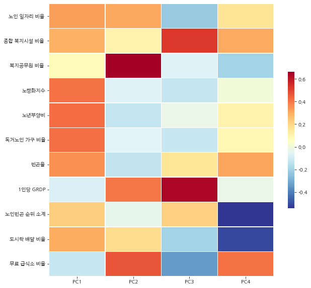

```python
fig, ax = plt.subplots( figsize=(10,10) )
sns.heatmap(pca_pd,
            cmap = 'RdYlBu_r',
            # annot = True,   # 실제 값을 표시한다
            linewidths=.5,  # 경계면 실선으로 구분하기
            cbar_kws={"shrink": .5},# 컬러바 크기 절반으로 줄이기
            # 컬러바 범위 -1 ~ 1
           )
```

PC1: 노령화지수, 노년부양비, 독거노인 가구 비율, 빈곤율

PC2: 복지공무원 비율 무료급식소 비율

pc3: 종합복지시설 비율, 1인당 GRDP

pc4: 노인빈곤순위 소계, 도시락 배달 비율

노인일자리 비율 삭제

노령화지수 = 노인부양비

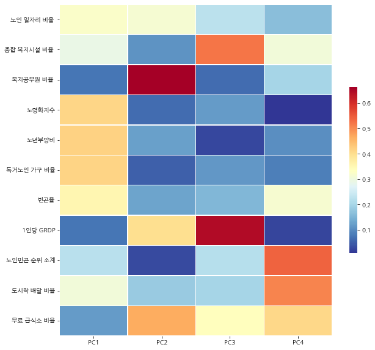

```python
fig, ax = plt.subplots( figsize=(10,10) )
sns.heatmap(abs(pca_pd),
            cmap = 'RdYlBu_r',
            # annot = True,   # 실제 값을 표시한다
            linewidths=.5,  # 경계면 실선으로 구분하기
            cbar_kws={"shrink": .5},# 컬러바 크기 절반으로 줄이기
            # 컬러바 범위 -1 ~ 1
           )
```

PC1: 노령화지수, 노년부양비, 독거노인가구비율, 빈곤율

```python
X_pp = pd.DataFrame(df_p,
                    columns = ['PC1','PC2','PC3','PC4'],
                    index = df.index)
X_pp
```

| 시군구 | PC1 | PC2 | PC3 | PC4 |
| --- | --- | --- | --- | --- |
| 가평군 | 5.886157 | 0.965747 | -0.776071 | -0.961304 |
| 고양시 | -1.169787 | -1.310285 | -0.462681 | -0.622051 |
| 과천시 | -1.521853 | 1.832423 | -0.103135 | -0.728311 |
| 광명시 | -0.994766 | -0.560504 | -1.113218 | -0.349584 |
| 광주시 | -2.167425 | -1.544433 | 0.162607 | -0.132536 |
| 구리시 | -0.355250 | 0.360413 | -1.135356 | 0.064947 |
| 군포시 | -1.365990 | 0.033239 | -1.457337 | 0.305286 |
| 김포시 | -1.303741 | -1.727575 | 0.738255 | -0.894876 |
| 남양주시 | -0.731728 | -1.842019 | -0.036537 | -0.381482 |
| 동두천시 | 2.258806 | 1.098399 | -1.774906 | 2.093718 |
| 부천시 | -1.112287 | -0.660776 | -0.826140 | -0.650144 |
| 성남시 | -1.520464 | 0.812101 | -1.512453 | 0.769297 |
| 수원시 | -1.793999 | -0.617625 | -0.047887 | -0.632229 |
| 시흥시 | -1.141043 | 2.442114 | -0.828197 | -0.201648 |
| 안산시 | -0.841820 | 1.932384 | -0.420972 | -1.310212 |
| 안성시 | 1.529534 | -0.670599 | 2.063703 | 1.495024 |
| 안양시 | -1.791759 | 0.283613 | -0.901989 | 0.406394 |
| 양주시 | -0.226705 | 0.015193 | -0.126798 | 0.418401 |
| 양평군 | 4.207195 | -1.903893 | 0.323781 | 1.873214 |
| 여주시 | 4.151204 | 0.856282 | 0.666606 | -0.397994 |
| 연천군 | 6.504118 | -0.171323 | -0.453545 | -1.482005 |
| 오산시 | -1.981329 | 1.583327 | -0.978064 | 1.272271 |
| 용인시 | -1.794887 | -1.622531 | 1.058241 | 0.212107 |
| 의왕시 | -0.231014 | 0.828204 | -0.975067 | -0.362346 |
| 의정부시 | -0.386136 | -1.868790 | -0.478339 | -0.424295 |
| 이천시 | -0.064481 | 1.724971 | 2.028005 | 1.897223 |
| 파주시 | 0.048741 | -0.920946 | 0.810457 | -0.703278 |
| 평택시 | -0.662269 | 0.258579 | 1.973606 | -0.128700 |
| 포천시 | 1.677323 | -0.404296 | 1.258383 | -0.311492 |
| 하남시 | -1.265570 | -2.025097 | 0.059808 | 0.664171 |
| 화성시 | -1.838777 | 2.823700 | 3.265238 | -0.797566 |

### 3. Plot

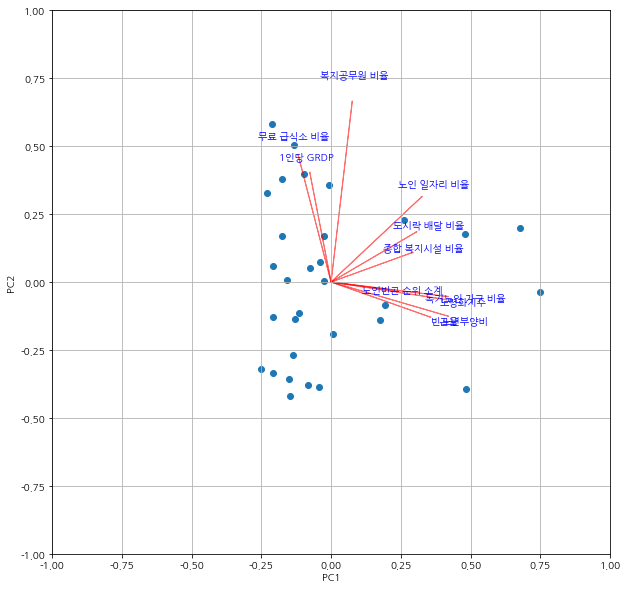

```python
def biplot(score,coeff,pcax,pcay,labels=None):
  plt.figure(figsize=(10,10))

  pca1=pcax-1
  pca2=pcay-1
  xs = score.iloc[:,pca1]
  ys = score.iloc[:,pca2]
  n=coeff.shape[0]
  scalex = 1.0/(xs.max()- xs.min())
  scaley = 1.0/(ys.max()- ys.min())
  plt.scatter(xs*scalex,ys*scaley)
  for i in range(n):
    plt.arrow(0, 0, coeff[i,pca1], coeff[i,pca2],color='r',alpha=0.5)
    if labels is None:
      plt.text(coeff[i,pca1]* 1.15, coeff[i,pca2] * 1.15, "Var"+str(i+1), color='b', ha='center', va='center')
    else:
      plt.text(coeff[i,pca1]* 1.15, coeff[i,pca2] * 1.15, labels[i], color='b', ha='center', va='center')
  plt.xlim(-1,1) # 범위는 최대 1에서 최소 -1
  plt.ylim(-1,1)
  plt.xlabel("PC{}".format(pcax))
  plt.ylabel("PC{}".format(pcay))
  plt.grid()

biplot(X_pp, pca.components_.T, 1, 2, labels=df.columns)
```

변수: '노인 일자리 비율 ', '종합 복지시설 비율 ', '복지공무원 비율 ', '노령화지수 (%)', '노년부양비 (%)', '독거노인 가구 비율', '빈곤율', '1인당 GRDP (만원,2016)', '노인빈곤 순위 소계', '도시락 배달 비율', '무료 급식소 비율'

따라서 PC1-> 양의 상관관계 요소들, PC2 -> 음의 상관관계 요소들로 볼 수 있다.

## FA

- Bartlett Test

```python
from factor_analyzer.factor_analyzer import calculate_bartlett_sphericity
chi_square_value, p_value = calculate_bartlett_sphericity(df_std)
chi_square_value, round(p_value) # p-value < 0.05 --> 귀무가설 기각
```

```
(342.1505878858528, 0)
```

- KMO Test
  - 변수들간 상관관계가 다른 변수에 의해 잘 설명되는 정도를 나타내는 값 (관측된 모든 변수 간 분산 비율)

```python
from factor_analyzer.factor_analyzer import calculate_kmo
kmo_all, kmo_model = calculate_kmo(df_std)
kmo_model # 0.62 로 평범한 편임.
```

```
0.6296149565826962
```

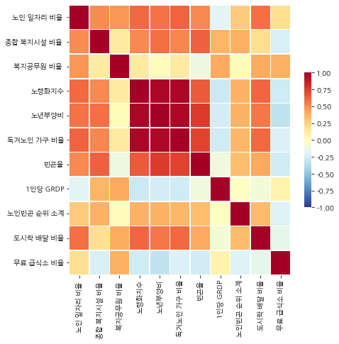

```python
fig, ax = plt.subplots( figsize=(7,7) )
sns.heatmap(df_std.corr(),
            cmap = 'RdYlBu_r',
            # annot = True,   # 실제 값을 표시한다
            linewidths=.5,  # 경계면 실선으로 구분하기
            cbar_kws={"shrink": .5},# 컬러바 크기 절반으로 줄이기
            vmin = -1,vmax = 1   # 컬러바 범위 -1 ~ 1
           )
plt.show()
```

4개의 factor로 진행

```python
fa = FactorAnalyzer(n_factors=4, rotation = "varimax")
fa.fit(df_std)
```

```
FactorAnalyzer(n_factors=4, rotation='varimax', rotation_kwargs={})
```

- Factor analysis (FA): 요인 적재량은 각 변수와 요인 간의 관계 정도를 나타내는 값으로, 일종의 회귀계수
  - 일반적으로 0.3 이상이면 유의미한 관계가 있다고 볼 수 있음
  - 제곱 값은 회귀계수의 결정계수($R^2$)와 같음 -> 해당 변수를 해당 요인이 얼마나 잘 설명해주는가

```python
fa_result_loading = pd.DataFrame(fa.loadings_,
                                 columns = ['Factor1', 'Factor2', 'Factor3', 'Factor4'],
                                 index=df_std.columns)
fa_result_loading
```

|  | Factor1 | Factor2 | Factor3 | Factor4 |
| --- | --- | --- | --- | --- |
| 노인 일자리 비율 | 0.629368 | 0.231616 | 0.034100 | 0.740275 |
| 종합 복지시설 비율 | 0.572562 | -0.145223 | 0.792670 | 0.180483 |
| 복지공무원 비율 | 0.075784 | 0.939518 | 0.192057 | 0.283070 |
| 노령화지수 | 0.966725 | 0.060199 | -0.073531 | 0.013241 |
| 노년부양비 | 0.981204 | -0.071082 | 0.019059 | -0.005548 |
| 독거노인 가구 비율 | 0.965226 | 0.037959 | -0.050321 | 0.065954 |
| 빈곤율 | 0.747151 | -0.225709 | 0.213602 | 0.112125 |
| 1인당 GRDP | -0.241217 | 0.353124 | 0.742313 | -0.161869 |
| 노인빈곤 순위 소계 | 0.425216 | -0.015560 | 0.149100 | -0.013436 |
| 도시락 배달 비율 | 0.643430 | 0.372157 | -0.088409 | 0.047533 |
| 무료 급식소 비율 | -0.319438 | 0.295856 | -0.073486 | 0.450734 |

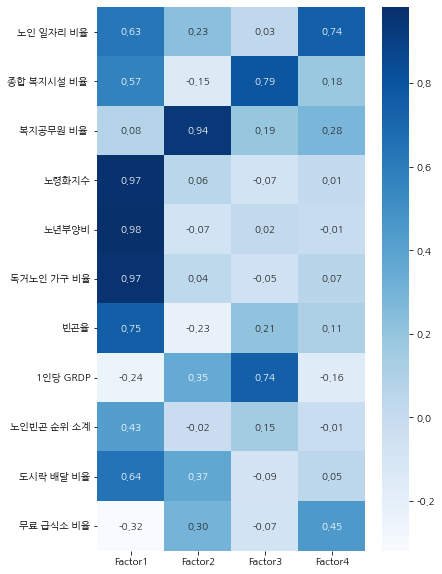

```python
# 시각화
plt.figure(figsize=(6,10))
sns.heatmap(fa_result_loading, cmap="Blues", annot=True, fmt='.2f')
```

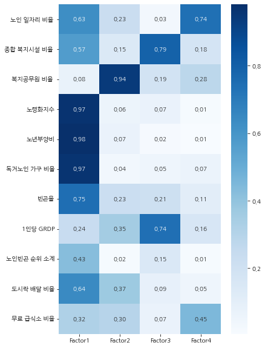

```python
# 시각화
plt.figure(figsize=(6,10))
sns.heatmap(np.abs(fa_result_loading), cmap="Blues", annot=True, fmt='.2f')
```

```python
fa.get_factor_variance() # 각 factor의 variance
fa_result_fromLoading = pd.DataFrame(fa.get_factor_variance(), columns = ['Factor1', 'Factor2', 'Factor3', 'Factor4'])
fa_result_fromLoading.index = ['SS Loadings', 'Proportion Var', 'Cumulative Var']
fa_result_fromLoading
```

|  | Factor1 | Factor2 | Factor3 | Factor4 |
| --- | --- | --- | --- | --- |
| SS Loadings | 4.871924 | 1.369462 | 1.306778 | 0.909641 |
| Proportion Var | 0.442902 | 0.124497 | 0.118798 | 0.082695 |
| Cumulative Var | 0.442902 | 0.567399 | 0.686197 | 0.768891 |

Factor1: 노령화지수, 노년부양비, 독거노인가구 비율

Factor2: 복지공무원 비율

Factor3: 종합복지시설 비율, 1인당 GRDP

Factor4: 노인일자리 비율, 무료 급식소 비율